# homework6

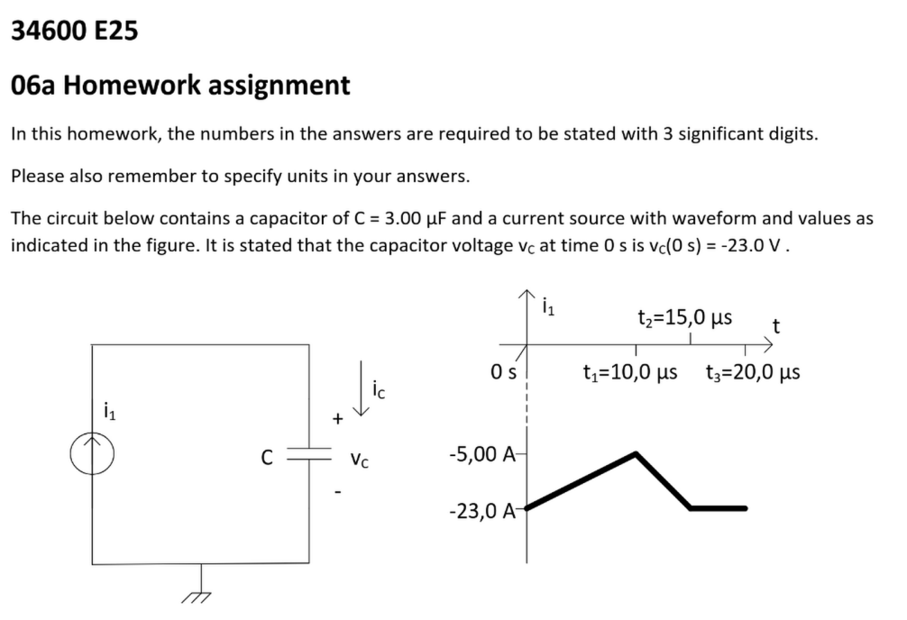

## Preface

Dot will be used as the decimal seperator

## Given

We are given:  
$C=3.00uF$  
$v_c(0)=-23.0V$  
And that graph.

# Task 1

Formula: $Q=\frac{1}{2} \cdot C \cdot v^2$  
We know C and v, so just insert and find Q

```python
from sympy import *
v = -23 # V
c = 3 # uF
q = (1/2)*c*v**2
print(f"Charged {N(q, 3)}uJ")
```

```
Charged 794uJ
```

Therefore the charged amount at t=0 is $Q=\boxed{794uJ}$

# Task 2

Formula $\Delta v=\frac{1}{C}\int_{0}^{t_1} i(t)\,dt$ and $v_C(t_1)=v_C(0)+\Delta v$, but $i(t)$ is linear, therfore $\frac{1}{C} \cdot \frac{i_0+i_1}{2}\cdot \Delta t = \Delta v$

We know:  
$v_c(0)=-23.0V$  
$i_0=-23.0A$  
$t_1=10.0uS$  
Now insert and find $v_c(t_1)$

```python
from sympy import *
i_0 = -23 # A
i_1 = -5 # A
t_1 = 10e-6 # S
c = 3e-6 # F
v0 = -23 # V
v1 = (1/c) * ((i_0+i_1)/2) * t_1
v_t1 = v0 + v1
print(f"V(t1): {N(v_t1, 3)}V")
```

```
V(t1): -69.7V
```

Therefore the capasitor voltage across at $t_1$ is $\boxed{-69.7V}$

# Task 3

Same formula from task 2, but with other values

```python
from sympy import *
i_0 = -5 # A
i_1 = -23 # A
t_0 = 10e-6 # S
t_1 = 15e-6 # S
c = 3e-6 # F
v2 = (1/c) * ((i_0+i_1)/2) * (t_1-t_0)
v_t2 = v_t1 + v2
print(f"V(t2): {N(v_t2, 3)}V")

from sympy import *
i_0 = -23 # A
i_1 = -23 # A
t_0 = 15e-6 # S
t_1 = 20e-6 # S
c = 3e-6 # F
v3 = (1/c) * ((i_0+i_1)/2) * (t_1-t_0)
v_t3 = v_t2 + v3
print(f"V(t2): {N(v_t3, 3)}V")
```

```
V(t2): -93.0V
V(t2): -131V
```

Therefore: $v_C(t_3)=\boxed{-131V}$

# Task 4

Same formula from task 1: $Q=\frac{1}{2} \cdot C \cdot v^2$  
Insert and solve

```python
from sympy import *
v = v_t3 # V
c = 3e-6 # F
q = (1/2)*c*v**2
print(f"Charged {N(q, 3)}J")
```

```
Charged 0.0259J
```

Which shows that the charge is $\boxed{Q(t_3)=0.0259J}$

# Task 5

We have these key points:  
$v_C(0)= -23.0\text{ V}$  
$v_C(t_1=10\,\mu s)= -69.7\text{ V}$  
$v_C(t_2=15\,\mu s)= -93.0\text{ V}$  
$v_C(t_3=20\,\mu s)= -131\text{ V}$ \

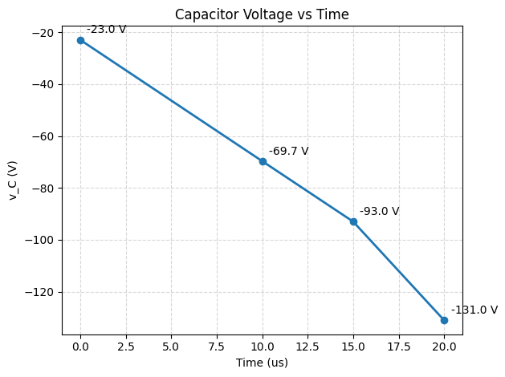

```python
import matplotlib.pyplot as plt
import numpy as np

t_us = np.array([0, 10, 15, 20], dtype=float)  # uS
vC   = np.array([-23.0, -69.7, -93.0, -131]) # V

plt.figure()
plt.plot(t_us, vC, marker='o', linewidth=2)
plt.xlabel('Time (us)')
plt.ylabel('v_C (V)')
plt.title('Capacitor Voltage vs Time')
plt.grid(True, linestyle='--', alpha=0.5)

for x, y in zip(t_us, vC):
    plt.annotate(f'{y:.1f} V', (x, y), textcoords='offset points', xytext=(6, 6))

plt.tight_layout()
plt.show()
```

# Next section

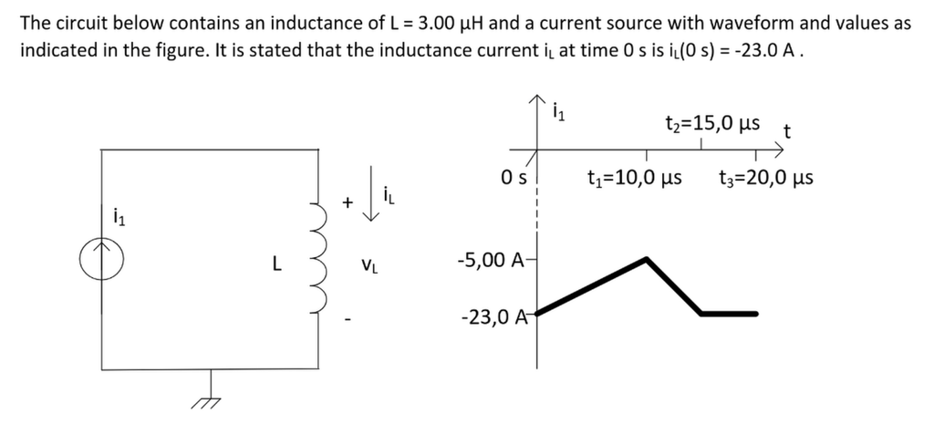

# Task 6

Formula: $w=\frac{1}{2} \cdot L \cdot i^2$  
And we are given:  
$L=3.00uH$  
$i(0)=-23.0A$  
Insert and find energy stored:

```python
l = 3e-6 # H
i = -23 # A
w = (1/2)*l*i**2
print(f"Energy stored: {N(w, 3)}J")
```

```
Energy stored: 0.000793J
```

Therefore the inductor has $\boxed{0.794mJ}$ stored inside at $t=0$

# Task 7

Formula: $v(t)=L\,\frac{di}{dt}.$  
Since the line is linearly rising, we just need the slope for the formula:

```python
print((-5 - -23)/10)
```

```
1.8
```

$\frac{\Delta i}{\Delta t} = 1.8 A/uS$ Now insert into fomula and get voltage:

```python
temp = ((-5 - -23)/10) * 1e6 # To amps/second
print(N(temp*l, 3))
```

```
5.40
```

Which leaves us with $\boxed{v(5us)=5.40V}$

# Task 8

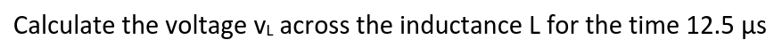

Same idea as before:

```python
print((-23 - -5)/(15-10))
```

```
-3.6
```

$\frac{\Delta i}{\Delta t} = -3.6 A/uS$  
Now insert into fomula and get voltage:

```python
temp = ((-23 - -5)/(15-10)) * 1e6 # To amps/second
print(N(temp*l, 3))
```

```
-10.8
```

Which leaves us with $\boxed{v(12.5us)=-10.8V}$

# Task 9

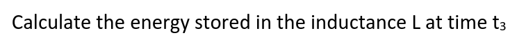

Formula for this is just the one from earlier: $w=\frac{1}{2} \cdot L \cdot i^2$

```python
l = 3e-6 # H
i = -23 # A
w = (1/2)*l*i**2
print(f"Energy stored: {N(w, 3)}J")
```

```
Energy stored: 0.000793J
```

Which shows that the charge is $\boxed{W(t_3)=0.793mJ}$

# Task 10

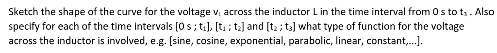

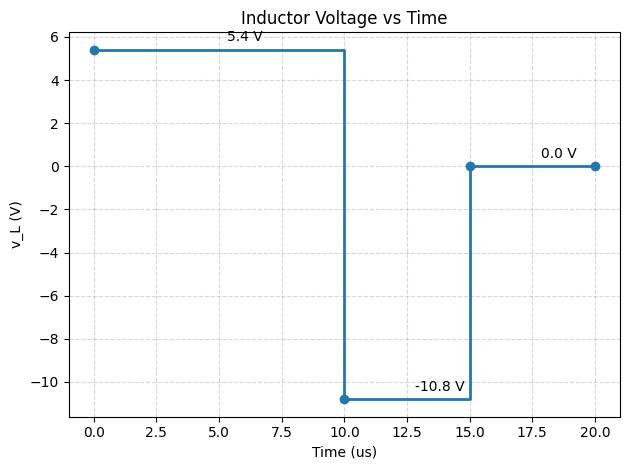

```python
import matplotlib.pyplot as plt
import numpy as np

t_us = np.array([0.0, 10.0, 15.0, 20.0])

vL_levels = np.array([5.4, -10.8, 0.0])

vL_for_step = np.r_[vL_levels, vL_levels[-1]]

plt.figure()
plt.step(t_us, vL_for_step, where='post', linewidth=2)
plt.scatter(t_us, vL_for_step, zorder=3)

plt.xlabel('Time (us)')
plt.ylabel('v_L (V)')
plt.title('Inductor Voltage vs Time')
plt.grid(True, linestyle='--', alpha=0.5)

midpoints = (t_us[:-1] + t_us[1:]) / 2
for x, y in zip(midpoints, vL_levels):
    plt.annotate(f'{y:.1f} V', (x, y), textcoords='offset points', xytext=(6, 6))

plt.tight_layout()
plt.show()
```

### Answer

$[0, t_1]$: (v = +5.40) V (flat)  
$[t_1, t_2]$: (v = -10.8) V (flat)  
$[t_2, t_3]$: (v = 0) V (flat)